# Mid-Decade Redistricting: The Same Votes, Different Seats

The Same Votes, Redrawn: Texas in 2025, Florida in 2026

Democracy’s Data

Last updated September 13, 2026 at 10:53a EDT

Texas held 17 statewide elections between 2016 and 2024, and every ballot in them has been counted. In 2025 the legislature redrew the state’s congressional districts, four years into a ten-year cycle, with the stated aim of electing five more Republicans. Those two facts make an unusual test possible. The votes are fixed; the lines are not. So you can ask a question that usually has no answer: with the same people voting exactly the way they already voted, does a new map send different people to Congress?

The question belongs to you rather than to a mapmaker. You cast one vote, in one place. Whether it lands in a district your side wins narrowly, loses narrowly, or wins by forty points is settled by other people, in a room, after the last election and before the next one. This brief pours already-counted votes into both sets of lines and reports what comes out.

## The test

Using 17 Texas statewide elections, 2016 through 2024, re-counted inside two congressional plans: the map Texas enacted in 2021 and the map that replaced it in 2025. Both re-counts come from Dave’s Redistricting (https://davesredistricting.org), a free public site. It rebuilds American elections at the precinct level, the few thousand voters who share one polling place, then re-sums them inside any district map you load.

Almost nothing else can answer this question. No agency reports statewide results inside a map that has never held an election. A private volunteer project does, which is why this site turns up wherever a proposed plan is argued about.

**Two files meet here, and the meeting is the whole method.** Precinct returns are joined to a district plan by geography: each precinct falls inside one district, and the district’s number is the label that comes back. Do that twice, once per plan, and the two results are then joined to each other on that number. The assumption is that district 28 in 2021 and district 28 in 2025 name comparable things.

Join Keys and Crosswalks works that kind of match on the best-behaved key in American data. It also says what to do when a key stops behaving: build a crosswalk, a table that translates one set of areas into another. Texas needed none. Florida, at the end of this brief, did.

Nothing in federal law stops a state from redrawing between censuses, which is what **mid-decade redistricting** means: a new map in the middle of the ten-year cycle rather than right after a count. Missouri, North Carolina and Tennessee have written their own bars into state law, and Texas has not.[^1] In *League of United Latin American Citizens v. Perry* (2006)[^2] the Supreme Court declined to treat a mid-decade redraw as presumptively partisan. *Rucho v. Common Cause* (2019)[^3] then closed the federal courts to partisan gerrymandering claims altogether. So the question is not whether the 2025 map was allowed. It was.

## The data

The table underneath everything here is `district_shares.csv`, one row per district per election, 646 rows. Each row carries `district`, `election` and `year`, then `share_old` and `share_new`: the Democratic share of the two-party vote inside the 2021 lines and inside the 2025 lines. A two-party share is the Democratic vote divided by the Democratic and Republican votes together, third parties set aside, so fifty per cent means tied. `seats_by_election.csv` collapses those rows to one per election, with `rep_old`, `rep_new` and `rep_gain`. `district_summary.csv` gives each district its `mean_old` and `mean_new` across all 17 races.

Three things happened to the votes before they reached those columns. Precincts cut by a district line were split, with votes shared out in proportion to population. Every district total was reduced to a two-party share. And the identical arithmetic was run twice, once per map, which is what makes the two columns comparable.

One further file carries a second join. `tx_overlap_pop.csv` holds `old`, `new`, `pop` and `weight`: how much of each 2021 district’s population sits inside each 2025 district. It is built by giving every 2020 census block group, a cluster of city blocks holding roughly six hundred to three thousand people, to whichever district contains its centre of population, under each plan in turn. That match is approximate, reproducing district totals to within about 1.5%, so read its shares to the point rather than to the decimal.

> **Before you scroll, write down two numbers.** Across 17 statewide elections, in how many does the new Texas map elect more Republicans than the old one, and in how many does it elect fewer?

## What it says about democracy

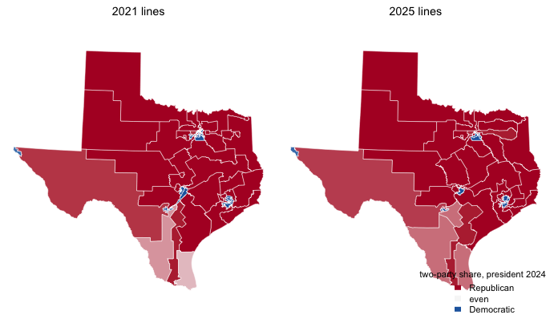

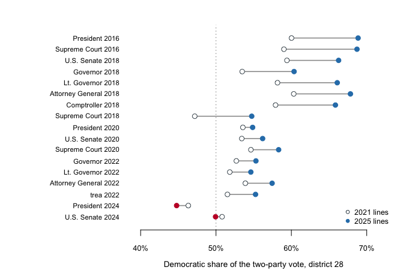

**Figure 1. Thirty-eight districts, two maps, one set of votes.** A map, because what the legislature changed was geography, and no other form lets you watch a boundary move. Every district is traced with the same number of points under both plans, so pressing the morph button slides the old shape into the new one. Color is the Democratic share of the two-party vote in the race you pick. Click a district to load all 17 of its elections. In print the two plans sit side by side, colored by the 2024 presidential race, with district 28 below.

The seat counts settle the aggregate question immediately. Count the districts where the Democratic share tops one-half, election by election, under each map. Take the 2024 presidential race. Under the 2021 lines, 11 of the 38 districts gave the Democratic candidate more than half of the two-party vote, so 27 went Republican. Pour the same precinct votes into the 2025 lines and 8 do, so 30 go Republican: 3 seats change hands with not one vote changed. Do that for all 17 races and every one of them elects more Republicans under the new lines: at least 2 more seats, at most 5, never zero and never negative.

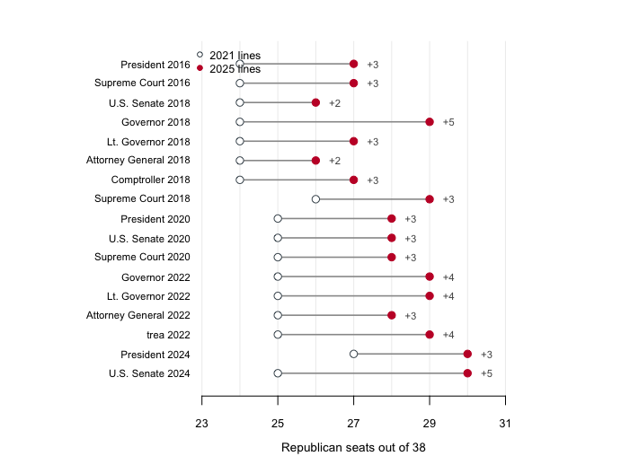

**Figure 2. The gain, race by race.** Each row re-counts one statewide election under both maps, and the dot never moves left. One row keeps the collection’s own shorthand: the 2022 race labeled `trea` arrives that way in the source export, and this brief will not guess at an office name the file does not state.

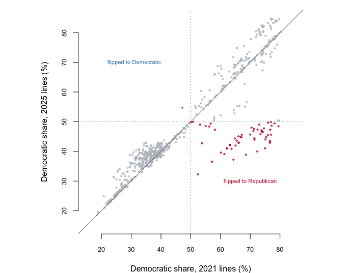

**Figure 3. What the swap did to every district at once.** One point per district per election, 646 of them, with the old share across and the new share up. Gray points barely move: most districts were already safe and stayed safe. The colored points are the exchange the map was drawn to make, a handful of Democratic-held districts pushed across the line with almost nothing pushed back.

**One district argues with that finding, and it is worth hearing out.** In August 2025 Representative Henry Cuellar told *POLITICO* that his redrawn 28th district might favor him more than the one it replaced (Benson 2025).[^4] He is reading real numbers. In the 2024 presidential race the new lines are worse for a Democrat, moving from 46.3% to 44.8% Democratic. But in 15 of the 17 races, all of them from 2016 through 2022, the new district is the bluer one.

The overlap table says where those voters came from. The new 28th keeps 53% of the people who lived in the old 28th and takes in 42% of the old 15th. Nearly half the district he is arguing about is territory he has never represented. His staff and the map’s drafter can both be right, because they are looking at different electorates: voters who backed Democrats reliably before 2024 and swung hard toward Trump in 2024. Which of those two turns out in 2026 is the bet the whole redraw rests on.

## The same test, run in Florida

Florida ran the same exercise a year later, and it comes out the same shape. The legislature replaced its congressional map in 2026. The same site re-counted 13 statewide elections from 2016 through 2024 inside the 2022 plan and the 2026 plan, with the same two-party arithmetic. Every one of the 13 races elects more Republicans under the new lines, from 1 to 4 more seats. Under the 2024 presidential race, Republican-carried districts go from 20 to 24 of 28. That is exactly the swing the map’s own drafters described in public as the point of the exercise.

Two things make Florida the harder case. Its constitution forbids drawing a district with the intent to favor a party, language voters added by initiative in 2010,[^5] and a state court has already voided one congressional plan under it.[^6] Every number above measures effect rather than intent, so it is the wrong shape for that rule, however plainly the drafters named the seat count they wanted.

The second difference is the join. The redraw renumbered 3 of Florida’s districts as well as redrawing them, so the district number stopped naming the same thing on both sides. Pairing the two plans took a crosswalk. Every one of Florida’s 2020 census blocks, the smallest areas the Bureau reports and often a single city block, was assigned into both maps, and each new district matched to the old one it drew most of its people from. That match is only a plurality: the old 23rd supplies 46.3% of the new 25th’s population, not a majority.

## What this brief cannot tell you

These are statewide contests re-counted inside district lines, not House contests. A House race has its own candidates, its own money and an incumbent voters know. Cuellar’s evidence came from House returns, which this data does not carry; the map’s drafter answered him with statewide returns, which it does. You have been reading the drafter’s kind of evidence, and should say so when you quote it.

The re-count also holds turnout fixed. It assumes the people who voted between 2016 and 2024 are the people who will vote in 2026, in the same numbers, with the same loyalties. Districts full of voters who changed sides recently, like the ones along the Texas border, are exactly where that assumption is weakest.

Nothing here reaches intent. The tables can say what the new lines do to votes already cast, precisely and in every election available. They cannot say why anyone drew them, which is the only question Florida’s constitution actually asks.

## Extensions

None of these is answered above, and every one can be answered from the tables the Sources section hands over.

- `seats_by_election.csv` replays every election on both maps and reports `rep_gain`. Count the elections where the new map does worse for its authors. What does a column with only one sign mean?
- `district_summary.csv` has `mean_old` beside `mean_new` for each district. Sort by the difference. Which districts absorbed the change, and which were left alone?
- `tx_overlap_pop.csv` gives the population shared between each old and new district as a `weight`. Find the districts that were rebuilt almost from scratch, and the ones that kept everybody.
- Pick one election in `district_shares.csv` and compare `share_old` against `share_new` across all districts. Do the shares move together, or does the map take from some and give to others?
- **Stretch.** Other states moved on their maps in the same cycle. Find one state’s before-and-after plans and check whether the one-sided pattern repeats.

## Sources

**Data**

- District-level results for 17 Texas statewide elections, 2016–2024, under the 2021 and 2025 congressional plans, from Dave’s Redistricting (https://davesredistricting.org), which rests on reconstructed precinct-level results from the official county canvasses. Boundary files for both plans come from the same site’s exports. The Florida figures are the same exercise on the 2022 and 2026 Florida plans, from the same site.
- 2020 Census centers of population by block group (`CenPop2020_Mean_BG48`, U.S. Census Bureau), used only to carry a block group’s people into the district that holds it under each plan. https://www2.census.gov/geo/docs/reference/cenpop2020/blkgrp/CenPop2020_Mean_BG48.txt
- 2020 Census population by block (`tl_2020_12_tabblock20`, U.S. Census Bureau TIGER/Line), used only to build Florida’s district crosswalk. https://www2.census.gov/geo/tiger/TIGER2020/TABBLOCK20/tl_2020_12_tabblock20.zip

**The data itself**

The Texas figures above are drawn from these tables. They are plain CSV, they open in a spreadsheet, and they are yours to take further.

`district_shares.csv`, `district_summary.csv`, `seats_by_election.csv`, `tx_overlap_pop.csv`, `tx-districts-tween.json`

One more file is not data about the subject – it is how this chapter checked its own numbers: `facts.csv`, the individual numbers the text above quotes.

**Cases, constitutions and state law**

- *League of United Latin American Citizens v. Perry*, 548 U.S. 399 (2006) — the challenge to Texas’s 2003 mid-decade map: no presumption against mid-decade redistricting, and District 23 struck under Section 2 of the Voting Rights Act. https://www.law.cornell.edu/supremecourt/text/05-204
- *Rucho v. Common Cause*, 588 U.S. 684 (2019). https://www.law.cornell.edu/supremecourt/text/18-422
- Fla. Const. art. III, §§ 20–21 (the Fair Districts amendments, adopted by initiative in 2010), https://www.flsenate.gov/Laws/Constitution, and *League of Women Voters of Florida v. Detzner*, 172 So. 3d 363 (Fla. 2015), holding the 2012 congressional plan drawn with intent to favor a party and its incumbents; summarised with its filings at https://thearp.org/litigation/league-women-voters-florida-v-detzner/.
- National Conference of State Legislatures, *Redistricting Law 2020* (Denver: NCSL, October 2019), ch. 10 for the states that bar mid-decade redistricting and ch. 6 for what *LULAC* settled. Frozen at 2019: a state could have added or repealed such a provision since.

**Academic literature**

- Grofman, B. and King, G. (2007). “The Future of Partisan Symmetry as a Judicial Test for Partisan Gerrymandering after *LULAC v. Perry*.” *Election Law Journal* 6(1): 2–35. https://gking.harvard.edu/files/gking/files/jp.pdf
- Cervas, J. and Grofman, B. (2020). “Tools for identifying partisan gerrymandering with an application to congressional districting in Pennsylvania.” *Political Geography* 76: 102069. https://doi.org/10.1016/j.polgeo.2019.102069

Why this data cannot be fetched again

```
The data behind this chapter cannot be downloaded again by a script, and
it is worth knowing why before you try.

WHY NOT. The two spreadsheets were exported from Dave's Redistricting
(https://davesredistricting.org), which rebuilds election results at
the precinct level and re-sums them inside any district map you load.
Each export is a manual download from a browser session with a
particular map open; there is no address a script can call to get the
same file. The copies shipped with this chapter are the archive.

WHAT EXISTS INSTEAD. The site itself, free after registration. Open
the enacted 2021 Texas congressional map and the 2025 replacement,
turn on any statewide election from 2016 through 2024, and the site
shows the same district-by-district shares these files hold. Exporting
them one election at a time rebuilds the two spreadsheets, columns for
president, governor, senator, and the rest, rows for districts 1
through 38.

WHAT YOU CAN STILL CHECK. However you come by the numbers, these say
whether you are holding the same object:
- 38 rows per file, one per district; 17 election columns; the long
  table assembled from them has 646 rows
- every cell is a Democratic share of the two-party vote, strictly
  between 0 and 1
- in the 2024 presidential race, Democratic candidates lead in 11
  districts under the old lines and 8 under the new
- across all 17 elections the new lines never elect fewer Republicans
  than the old ones; the gain runs from 2 seats to 5
```

[^1]: National Conference of State Legislatures, *Redistricting Law 2020* (Denver: NCSL, 2019), ch. 10, https://www.ncsl.org/redistricting-and-census/redistricting-law-2020.
[^2]: 548 U.S. 399 (2006): https://www.law.cornell.edu/supremecourt/text/05-204.
[^3]: 588 U.S. 684 (2019): https://www.law.cornell.edu/supremecourt/text/18-422.
[^4]: He had said the same to local television the week the map passed: KGNS-TV, “Rep. Cuellar says new Texas map makes his district more Democratic,” 25 August 2025, https://www.kgns.tv/2025/08/25/rep-cuellar-says-new-texas-map-makes-his-district-more-democratic/.
[^5]: Fla. Const. art. III, § 20(a): https://www.flsenate.gov/Laws/Constitution.
[^6]: *League of Women Voters of Florida v. Detzner*, 172 So. 3d 363 (Fla. 2015). The case and its filings are summarised by the American Redistricting Project: https://thearp.org/litigation/league-women-voters-florida-v-detzner/.